# Become an R Data Ninja!

Jenny Smetzer & Albert Y. Kim

Last updated on 2019-02-27

Let’s load all the packages we’re going to need on your journey to becoming an R ninja!

```r
library(dplyr)
library(ggplot2)
library(readr)
library(knitr)
library(scales)
```

# Reading data into R

You will need to bring your project data into R. So far all the data we have used in class has mostly been built into packages. Your project data will likely be in an Excel spreadsheet. For your project, instead of submitting this Excel spreadsheet, you can publish (non-sensitive and non-private) data to the web so it can be easily read into R. The advantage to this approach for your project is that

- It is an easy way to share the data with very person in your group and the instructor without having to pass around the Excel file.
- If **one person** in the group makes a change to the data file, **everyone else** in the group will have those changes updated when they bring the data into R.

Here are [instructions](https://twitter.com/rudeboybert/status/1055821833512071168) on how to do this; follow through “Step 5: Copy the URL to the published CSV.” The next step is to copy, paste, and adapt the code block below:

```r
library(readr)
my_data <- read_csv("paste_the_url_here")
```

1. Put the URL of your published CSV file where it says `paste_the_url_here`. Be sure you include the **quotation marks**!
2. Name the data frame whatever you want it to be called. Here we named it `my_data`

Only one person in the group should do this step. However, once the google sheet is published, make sure to **share** the original Google Sheet with everyone else in your project, so anyone in your group can make changes to the data.

For example, take a look at the following [Google Sheet](https://docs.google.com/spreadsheets/d/1JIeADfp3ky3xExXWQz5lxbB0Tx5bTo0BA0sH6bzAqAA/edit?ts=5c75a9a5#gid=1970549377) of movie data. Following the above mentioned [instructions](https://twitter.com/rudeboybert/status/1055821833512071168), we “published” the Google Sheet as a CSV, and thus anyone in the world can load into R as follows:

```r
movies <- read_csv("https://docs.google.com/spreadsheets/d/e/2PACX-1vSw7gf9uPFvUBpk5NoL1oX-S6g-eWBYVThEDPLPXqYzkYXtNyYtVrcf2cSpnNpZLdGWsk-WunvYYN27/pub?gid=1970549377&single=true&output=csv")
```

Let’s preview the first 10 rows of `movies` using the `slice()` function from the `dplyr` package:

```r
library(dplyr)
movies %>%
  slice(1:10)
```

```
## # A tibble: 10 x 6
##    name             score rating type       millions over200
##    <chr>            <dbl> <chr>  <chr>         <dbl>   <int>
##  1 2 Fast 2 Furious  48.9 PG-13  action        NA          0
##  2 28 Days Later     78.2 R      horror        45.1        0
##  3 A Guy Thing       39.5 PG-13  rom comedy    15.5        0
##  4 A Man Apart       42.9 R      action        26.2        0
##  5 A Mighty Wind     79.9 PG-13  comedy        17.8        0
##  6 Agent Cody Banks  57.9 PG     action        47.8        0
##  7 Alex & Emma       35.1 PG-13  rom comedy    14.2        0
##  8 American Wedding  50.7 R      comedy       104.         0
##  9 Anger Management  62.6 PG-13  comedy       134.         0
## 10 Anything Else     63.3 R      rom comedy     3.21       0
```

# Common data wrangling

Here are some commonly performed data wrangling operations.

## Dealing with missing values

Looking at our preview above, you see the revenue in `millions` value for the movie “2 Fast 2 Furious” is `NA` i.e. missing. It is always good to check for missing values in your data set. The following takes a sum of all the missing values in the data set for each column.

```r
colSums(is.na(movies))
```

```
##     name    score   rating     type millions  over200
##        0        0        0        0        1        0
```

```r
movies %>%
  summarize(mean_profit = mean(millions))
```

```
## # A tibble: 1 x 1
##   mean_profit
##         <dbl>
## 1          NA
```

You should always think about why a data value might be missing and what that missingness may mean. For example, imagine you are conducting a study on the effects of smoking on lung cancer and a lot of your patients’ data is missing because they died of lung cancer. If you just “sweep these patients under the rug” and ignore them, you are clearly biasing the results.

While there are statistical methods to deal with missing data they are beyond the reach of this class. The easiest thing to do is to remove all missing cases, but **you should always at the very least report to the reader if you do so, as by removing the missing values you may be biasing your results.**

You can do this with a `na.rm = TRUE` argument like so:

```r
movies %>%
  summarize(mean_profit = mean(millions, na.rm = TRUE))
```

```
## # A tibble: 1 x 1
##   mean_profit
##         <dbl>
## 1        60.6
```

If you decide you want to remove rows with missing values for `millions`, you can use the `filter()` function like so:

```r
movies <- movies %>%
  filter(!is.na(millions))

movies %>%
  slice(1:10)
```

```
## # A tibble: 10 x 6
##    name             score rating type       millions over200
##    <chr>            <dbl> <chr>  <chr>         <dbl>   <int>
##  1 28 Days Later     78.2 R      horror        45.1        0
##  2 A Guy Thing       39.5 PG-13  rom comedy    15.5        0
##  3 A Man Apart       42.9 R      action        26.2        0
##  4 A Mighty Wind     79.9 PG-13  comedy        17.8        0
##  5 Agent Cody Banks  57.9 PG     action        47.8        0
##  6 Alex & Emma       35.1 PG-13  rom comedy    14.2        0
##  7 American Wedding  50.7 R      comedy       104.         0
##  8 Anger Management  62.6 PG-13  comedy       134.         0
##  9 Anything Else     63.3 R      rom comedy     3.21       0
## 10 Bad Boys II       38.1 R      action       138.         0
```

We see “2 Fast 2 Furious” is now gone. The `filter()` code says keep only rows in this data set in which the variable `millions` is not NA; `!` means NOT in computer programming.

## log10 transformations

You might find that you need to create a new variable and add it to your data frame. For instance, suppose we wanted to log base 10 transform the `millions` variable in the movies data. (`millions` is the amount of $ each movie made). For example, since one million is 10<sup>6</sup>, `log10(1000000)` is equal to 6.

The following code adds the variable `log10_mill` to the movies data, which is the log 10 of the millions variable:

```r
movies <- movies %>%
  mutate(log10_mill = log10(millions))
movies
```

```
## # A tibble: 139 x 7
##    name             score rating type       millions over200 log10_mill
##    <chr>            <dbl> <chr>  <chr>         <dbl>   <int>      <dbl>
##  1 28 Days Later     78.2 R      horror        45.1        0      1.65
##  2 A Guy Thing       39.5 PG-13  rom comedy    15.5        0      1.19
##  3 A Man Apart       42.9 R      action        26.2        0      1.42
##  4 A Mighty Wind     79.9 PG-13  comedy        17.8        0      1.25
##  5 Agent Cody Banks  57.9 PG     action        47.8        0      1.68
##  6 Alex & Emma       35.1 PG-13  rom comedy    14.2        0      1.15
##  7 American Wedding  50.7 R      comedy       104.         0      2.02
##  8 Anger Management  62.6 PG-13  comedy       134.         0      2.13
##  9 Anything Else     63.3 R      rom comedy     3.21       0      0.507
## 10 Bad Boys II       38.1 R      action       138.         0      2.14
## # … with 129 more rows
```

The following code does the same thing, but rounds the output to 2 decimal points.

```r
movies <- movies %>%
  mutate(
    log10_mill = log10(millions),
    log10_mill = round(log10_mill, 2)
  )
```

## Computing proportions

How do I compute proportions? By using a `group_by()`, but not followed by a `summarize()` as is often the case, but rather a `mutate()`. So say we compute the total revenue millions for each movie rating and type:

```r
rating_by_type_millions <- movies %>%
  group_by(rating, type) %>%
  summarize(millions = sum(millions)) %>%
  arrange(rating, type)

rating_by_type_millions
```

```
## # A tibble: 26 x 3
## # Groups:   rating [4]
##    rating type      millions
##    <chr>  <chr>        <dbl>
##  1 G      animated    496.
##  2 PG     action       47.8
##  3 PG     adventure   112.
##  4 PG     animated     65.7
##  5 PG     comedy      830.
##  6 PG     drama       161.
##  7 PG     fantasy     147.
##  8 PG     musical       4.93
##  9 PG-13  action     1479.
## 10 PG-13  adventure    65.7
## # … with 16 more rows
```

Say within each movie `rating` (G, PG, PG-13, R), we want to know the proportion of `total_millions` that made by each movie `type` (animated, action, comedy, etc). We can:

```r
rating_by_type_millions %>%
  group_by(rating) %>%
  mutate(
    # Compute a new column of the sum of millions split by rating:
    total_millions = sum(millions),
    # Compute the proportion within each rating:
    prop = millions/total_millions
    )
```

```
## # A tibble: 26 x 5
## # Groups:   rating [4]
##    rating type      millions total_millions    prop
##    <chr>  <chr>        <dbl>          <dbl>   <dbl>
##  1 G      animated    496.             496. 1
##  2 PG     action       47.8           1368. 0.0349
##  3 PG     adventure   112.            1368. 0.0817
##  4 PG     animated     65.7           1368. 0.0480
##  5 PG     comedy      830.            1368. 0.606
##  6 PG     drama       161.            1368. 0.118
##  7 PG     fantasy     147.            1368. 0.108
##  8 PG     musical       4.93          1368. 0.00360
##  9 PG-13  action     1479.            4174. 0.354
## 10 PG-13  adventure    65.7           4174. 0.0157
## # … with 16 more rows
```

So for example:

- For `rating` equals G there is only one `type` of movie (animated), the proportion of `total_millions` is 1.
- For `rating` equals PG there are 7 `type` of movies (action, adventure, animated, comedy, drama, fantasy, and musical), so the 7 proportions are 0.0349 + 0.0817 + 0.0480 + 0.606 + 0.118 + 0.108 + 0.0036 = 1.

## How do I deal with %, commas, and $?

Often time variables that are in theory numerical are saved as text data because of the presence of perctage signs, commas, and dollar signs. How do you convert these to numerical values? Using `parse_number()` from the `readr` package inside a `mutate()`! Shout out to [Stack Overflow](https://stackoverflow.com/a/52965808/3674500)

```r
library(readr)
parse_number("10.5%")
```

```
## [1] 10.5
```

```r
parse_number("145,897")
```

```
## [1] 145897
```

```r
parse_number("$1,234.5")
```

```
## [1] 1234.5
```

What about converting the other way around? Use the `scales` package!

```r
library(scales)
percent(0.105)
```

```
## [1] "10.5%"
```

```r
comma(145897)
```

```
## [1] "145,897"
```

```r
dollar(1234.5)
```

```
## [1] "$1,234.50"
```

# Categorical variables

Working with categorical variables in R can be tricky. However it is an essential tool given that so much of the world’s data is categorical in nature.

## Inspecting levels of a categorical variable

Sometimes it is useful to find out what all the *levels* are for a categorical variable (in other words the variable’s possible categories) and to count how many cases are in each of the levels. The following code gives us a count of each level of the `rating` categorical variable:

```r
movies %>%
  group_by(rating) %>%
  tally()
```

```
## # A tibble: 4 x 2
##   rating     n
##   <chr>  <int>
## 1 G          4
## 2 PG        21
## 3 PG-13     64
## 4 R         50
```

The following code tells us all the distinct types of movies in the `type` column:

```r
movies %>%
  distinct(type)
```

```
## # A tibble: 13 x 1
##    type
##    <chr>
##  1 horror
##  2 rom comedy
##  3 action
##  4 comedy
##  5 suspense
##  6 drama
##  7 animated
##  8 fantasy
##  9 sci-fi
## 10 documentary
## 11 musical
## 12 adventure
## 13 western
```

## Create a categorical variable from a numerical one

```r
movies <- movies %>%
  mutate(big_money = as.factor(millions > 100))
```

Here we create a new column called `big_money` and fill it with `TRUE` or `FALSE` values based on whether the values in the column `millions` are greater than 100 or not. We use the `as.factor()` to ensure the output is a factor, R’s way of saving categorical variables.

Again, check your work

```r
movies %>%
  select(name, millions, big_money) %>%
  glimpse()
```

```
## Observations: 139
## Variables: 3
## $ name      <chr> "28 Days Later", "A Guy Thing", "A Man Apart", "A Migh…
## $ millions  <dbl> 45.065, 15.545, 26.248, 17.781, 47.811, 14.219, 104.44…
## $ big_money <fct> FALSE, FALSE, FALSE, FALSE, FALSE, FALSE, TRUE, TRUE, …
```

Let’s count the number of big money and non-big money movies:

```r
movies %>%
  group_by(big_money) %>%
  tally()
```

```
## # A tibble: 2 x 2
##   big_money     n
##   <fct>     <int>
## 1 FALSE       112
## 2 TRUE         27
```

What if instead you want to recode a numeric variable into a categorical variable with more than 2 levels? One way is to use the `cut()` command.

For instance, below, we `cut` the `score` variable, to recode it into 4 categories:

1. 0-40 = bad
2. 40.1-60 = so-so
3. 60.1 - 80 = good
4. 80.1+ = great.

We set the breaking points for cutting the numeric variable with the `c(0, 40, 60, 80, 100)` part, and set the labels for each of these bins with the `labels = c("bad", "so-so", "good", "great")` part. All this action happens inside the `mutate()` command, so the new categorical variable `scorecats` is added to the data frame.

```r
movies <- movies %>%
  mutate(scorecat = cut(score,
                        breaks = c(0, 40, 60, 80, 100),
                        labels = c("bad", "so-so", "good", "great")
                        ) # this closes the cut parentheses
  ) # this closes the mutate parentheses
```

## Reclassify the levels of a categorical variable

Sometimes categorical variables have too many levels or values for us to include in a statistical analysis. For instance, there are 13 movie types! We can re-classify each movie into one of five categories instead: `act_adv`, `sci_fantasy`, `funny`, `serious`, and `scary`. We’ll call the new variable `type_cat`.

We will use the `recode_factor()` code from the dplyr package. The recoding is illustrated below. Recall that `mutate()` adds new columns. The new column we create below is called `type_cat`, the column we are recoding is `type`. The the only reason the names are on separate lines is to make the code easier to read.

```r
movies <- movies %>%
  mutate(type_cat = recode_factor(
    type,
    "action" = "act_adv",
    "adventure" = "act_adv",
    "horror" = "scary",
    "suspense" = "scary",
    "drama" = "serious",
    "western" = "serious",
    "documentary" = "serious",
    "rom comedy" = "funny",
    "comedy" = "funny",
    "animated" = "funny",
    "musical" = "funny",
    "fantasy" = "sci_fantasy",
    "sci-fi" = "sci_fantasy")
  )
```

Again, check your work

```r
movies %>%
  select(name, type, type_cat) %>%
  glimpse()
```

```
## Observations: 139
## Variables: 3
## $ name     <chr> "28 Days Later", "A Guy Thing", "A Man Apart", "A Might…
## $ type     <chr> "horror", "rom comedy", "action", "comedy", "action", "…
## $ type_cat <fct> scary, funny, act_adv, funny, act_adv, funny, funny, fu…
```

Let’s count the number of each `type_cat` movies:

```r
movies %>%
  group_by(type_cat) %>%
  tally()
```

```
## # A tibble: 5 x 2
##   type_cat        n
##   <fct>       <int>
## 1 act_adv        31
## 2 scary          21
## 3 serious        22
## 4 funny          59
## 5 sci_fantasy     6
```

## Re-order how categorical variables are plotted

When you make a boxplot or barplot, R may not always put the levels of the categorical variable on the x axis in the order you like. In fact by default R arranges them in alphanumeric order. For instance, the boxplot of `millions` for each rating shows the boxes from G to R like so:

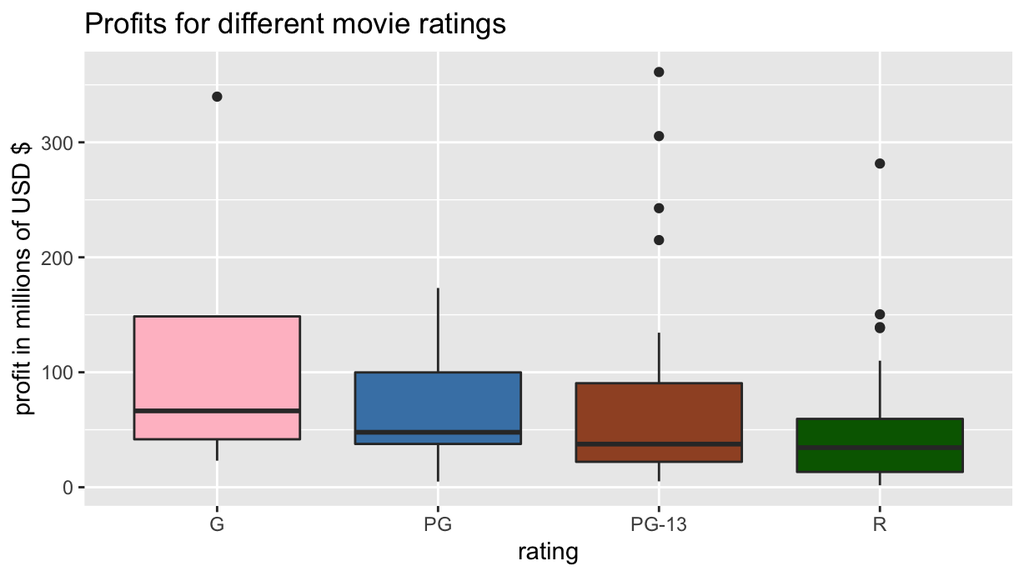

```r
library(ggplot2)
ggplot(data = movies, aes(x = rating, y = millions)) +
  geom_boxplot(fill = c("pink", "steelblue", "sienna", "darkgreen")) +
  labs(x = "rating", y = "profit in millions of USD $",
       title = "Profits for different movie ratings")
```

To define our own order for the categorical variable, we can do the following:

```r
movies <- movies %>%
  mutate(rating = factor(rating, levels = c("G", "PG", "PG-13", "R")))
```

This mutates or makes a new column that holds the same variable name, but tells R that we want the levels ordered `c("G", "PG", "PG-13", "R")`. The new boxplot reflects this:

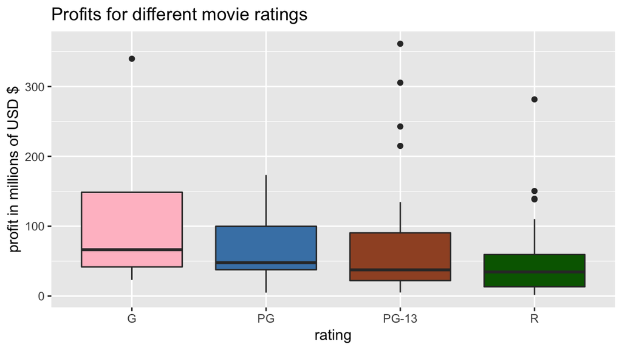

```r
ggplot(data = movies, aes(x = rating, y = millions)) +
 geom_boxplot(fill = c("pink", "steelblue", "sienna", "darkgreen")) +
  labs(x = "rating", y = "profit in millions of USD $",
       title = "Profits for different movie ratings")
```

# Formatting

## Plotting dollar values on an axis

Observe the y-axis on the following plot:

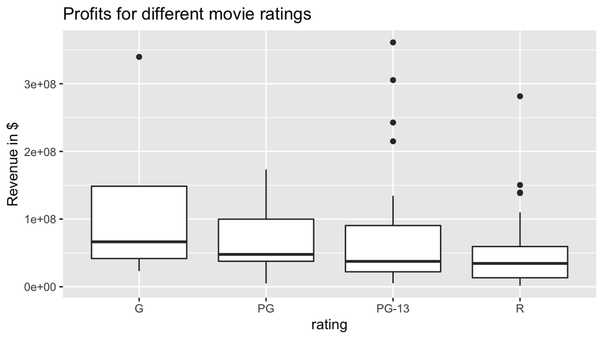

```r
movies <- movies %>%
  mutate(revenue = millions * 10^6)

ggplot(data = movies, aes(x = rating, y = revenue)) +
  geom_boxplot() +
  labs(x = "rating", y = "Revenue in $", title = "Profits for different movie ratings")
```

While we might understand that `2e+08` is 2 $\times 10^8$ = 200,000,000, your audience might not. How can we change this? Googled “ggplot2 axis scale dollars”, click on the [first link](http://www.sthda.com/english/wiki/ggplot2-axis-scales-and-transformations), search for the word “dollars”. You’ll find:

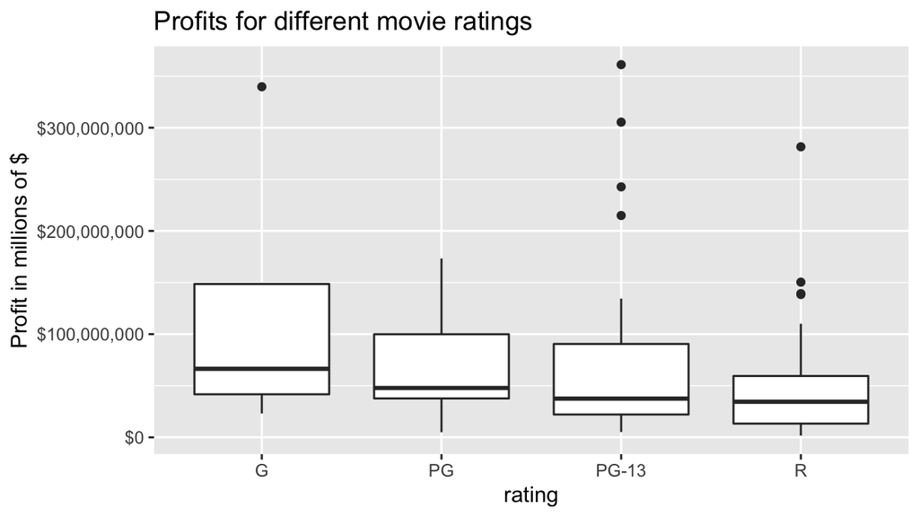

```r
library(scales)
ggplot(data = movies, aes(x = rating, y = revenue)) +
  geom_boxplot() +
  labs(x = "rating", y = "Profit in millions of $",
       title = "Profits for different movie ratings") +
  scale_y_continuous(labels = dollar)
```

## R Markdwon formatting

Here are some ways to format text in R Markdown:

*italicize*

**bold**

> Emphasis blocks! You can spell check in R!!!! Go to the edit tab at the upper left part of the screen…the Check spelling option is near the bottom. Also, check out in the knitted file what putting the > before this text accomplished!

Here are some common mathematical symbols:

$\mu$

$\sqrt(x)$

$\beta_{1}$

$\hat{y}$

$\alpha = 0.05$

## Code chunk outputs

We can format how the code chunks show up in RMarkdown documents by adding arguments inside the `{r}` section. A few examples are below

**Show the code output, but not the code**

```
## # A tibble: 4 x 3
##   rating `Average Rating Score` `Sample Size`
##   <fct>                   <dbl>         <int>
## 1 G                        67.6             4
## 2 PG                       55.1            21
## 3 PG-13                    55.9            64
## 4 R                        55.6            50
```

**Show the code output, but not the code…and make a table look really nice when you knit**

You must install the `knitr` package and open it. The `digits = 2` argument signifies we round to two decimal places.

| rating | Average Rating Score | Sample Size |
| --- | --- | --- |
| G | 67.65 | 4 |
| PG | 55.06 | 21 |
| PG-13 | 55.94 | 64 |
| R | 55.63 | 50 |

**Run some code, but don’t include it in the output when you knit**

Notice I also set the size of the figure that is printed

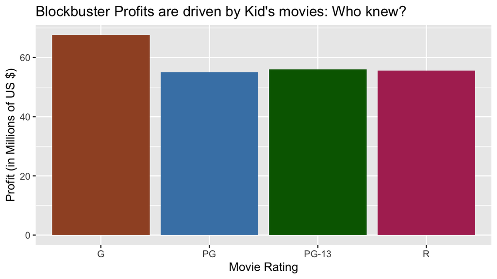

```r
ggplot(data = movies_summaries, aes(x = rating, y = `Average Rating Score`)) +
  geom_bar(stat = "identity", fill = c("sienna", "steelblue", "darkgreen", "maroon")) +
  labs(x = "Movie Rating", y = "Profit (in Millions of US $)",
       title = "Blockbuster Profits are driven by Kid's movies: Who knew?")
```

**Show the code and not the output**

```r
glimpse(movies)
```

**Show neither the code or the output**

# Congratulations!

You are now an R Ninja!!